# Practical Machine Learning - Prediction Assignment

Jacques du Plessis

23 September 2018

## Assignment

The goal of the project is to predict the manner in which they did the exercise. This is the “classe” variable in the training set.

The report describes:

- How the data was prepared;
- How the model was built;
- The cross validation strategy employed;
- The expected out of sample error.

## Background

Six young health participants were asked to perform one set of 10 repetitions of the Unilateral Dumbbell Biceps Curl in five different fashions: exactly according to the specification (Class A), throwing the elbows to the front (Class B), lifting the dumbbell only halfway (Class C), lowering the dumbbell only halfway (Class D) and throwing the hips to the front (Class E).

Class A corresponds to the specified execution of the exercise, while the other 4 classes correspond to common mistakes. Participants were supervised by an experienced weight lifter to make sure the execution complied to the manner they were supposed to simulate. The exercises were performed by six male participants aged between 20-28 years, with little weight lifting experience. We made sure that all participants could easily simulate the mistakes in a safe and controlled manner by using a relatively light dumbbell (1.25kg).

See: http://web.archive.org/web/20161224072740/http:/groupware.les.inf.puc-rio.br/har

## Read the data

```r
library(data.table)

## Read training file
traifilename <- paste(getwd(),"/data/pml-training.csv",sep="")
pmltraindf <-  fread(traifilename,na.strings=c("NA","N/A","null",""))

## Read testing file
testfilename <- paste(getwd(),"/data/pml-testing.csv",sep="")
pmltestdf <-  fread(testfilename,na.strings=c("NA","N/A","null",""))

## Remove variables
rm(traifilename)
rm(testfilename)
```

## Exploratory Data Analysis

The dataset contains 19622 and 160 columns.

The first seven columns are not related to sensors data and should be removed before taining the model:

```r
names(pmltraindf)[1:7]
```

```
## [1] "V1"                   "user_name"            "raw_timestamp_part_1"
## [4] "raw_timestamp_part_2" "cvtd_timestamp"       "new_window"
## [7] "num_window"
```

```r
pmltraindf <- pmltraindf[,-c(1:7)]
pmltestdf <- pmltestdf[,-c(1:7)]
```

## Data cleanup

The dataset contains many NA & NaN values. The is.na() function will remove both.

```r
## Make NA equal to zero
## Note that is.na will also pick up the NaN values
pmltraindf[is.na(pmltraindf)] <- 0
```

There are many column with near zero values. The nearZeroVar are used to trim the remaining columns

```r
library(caret)
examinedf <- nearZeroVar(pmltraindf, saveMetrics=TRUE)
drop <- row.names(examinedf[which(examinedf$nzv==TRUE),])
pmltraindf <- as.data.frame(pmltraindf)
pmltestdf <- as.data.frame(pmltestdf)
##Drop columns with zeroVAR.
pmltraindf <- pmltraindf[ , !(names(pmltraindf) %in% drop)]
pmltestdf <- pmltestdf[ , !(names(pmltestdf) %in% drop)]
```

## Machine Learning Model

The machine learning approach was based on these guiding principles:

- Given the large set of predictors, I decided to select a RandomForest approach
- The caret package train function was used;
- with 10-fold cross validation;
- The testing set does not contain the classe. The Training Data was further split with a 60% training and 40% validation set ratio to provide a indication of out of sample error

```r
pmltraindf$classe <- as.factor(pmltraindf$classe)
set.seed(743)
inTrain <- createDataPartition(pmltraindf$classe, p = 0.6)[[1]]
trainingdf <- pmltraindf[ inTrain,]
validationdf <- pmltraindf[-inTrain,]

## Enable parallel processing
library(parallel)
library(doParallel)
cluster <- makeCluster(detectCores())
registerDoParallel(cluster)

library(caret)
train_control <- trainControl(method="cv", number=10,allowParallel = TRUE)
set.seed(743)
exectime <- system.time({
    modelfit <- train(classe~., data=trainingdf, trControl=train_control, method="rf" )
})

## Disable parallel processing
stopCluster(cluster)
registerDoSEQ()
rm(cluster)
```

### Execution time

Using parallel processing (with 8 cores), the model training time was:

```
##    user  system elapsed
##   33.19    0.16  332.43
```

### Model output

Here is the results of the model using 10-fold cross validation:

```
## Random Forest
##
## 11776 samples
##    52 predictor
##     5 classes: 'A', 'B', 'C', 'D', 'E'
##
## No pre-processing
## Resampling: Cross-Validated (10 fold)
## Summary of sample sizes: 10599, 10598, 10598, 10598, 10598, 10599, ...
## Resampling results across tuning parameters:
##
##   mtry  Accuracy   Kappa
##    2    0.9901490  0.9875372
##   27    0.9902340  0.9876463
##   52    0.9818273  0.9770099
##
## Accuracy was used to select the optimal model using the largest value.
## The final value used for the model was mtry = 27.
```

### Variable importance

The following Varaibles Importance is assigned by the model:

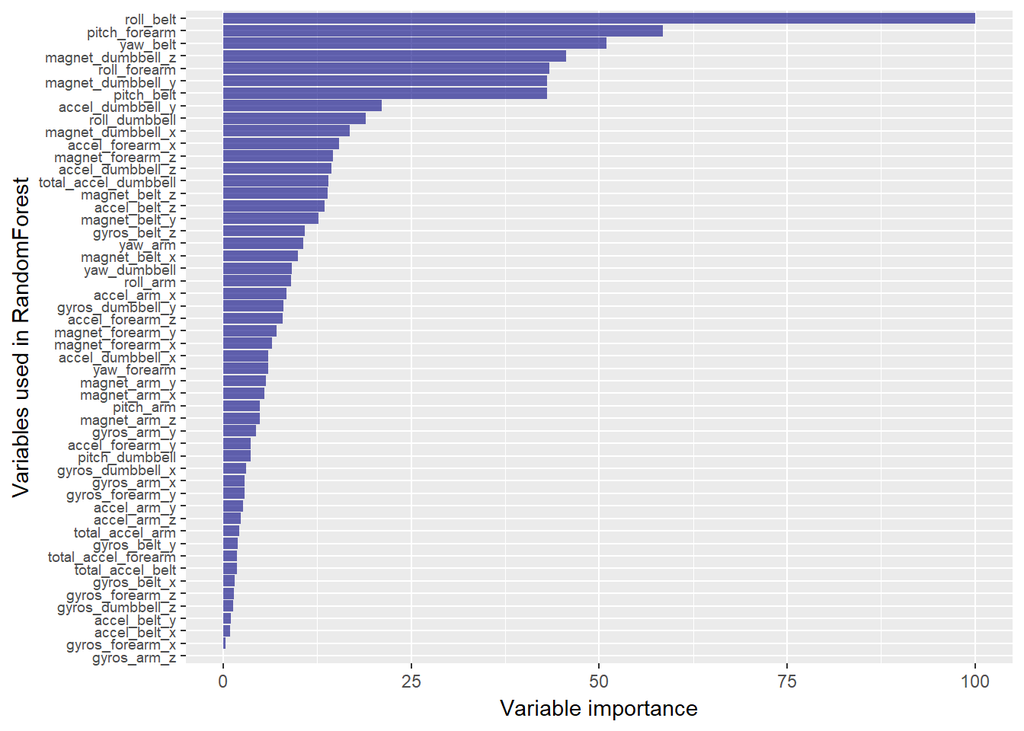

Here is the Variable importance in text format:

```
##                              VariableName  Importance
## roll_belt                       roll_belt 100.0000000
## pitch_forearm               pitch_forearm  58.4362114
## yaw_belt                         yaw_belt  50.9291338
## magnet_dumbbell_z       magnet_dumbbell_z  45.6018390
## roll_forearm                 roll_forearm  43.3764693
## magnet_dumbbell_y       magnet_dumbbell_y  43.0278544
## pitch_belt                     pitch_belt  43.0178994
## accel_dumbbell_y         accel_dumbbell_y  21.0912159
## roll_dumbbell               roll_dumbbell  18.8928737
## magnet_dumbbell_x       magnet_dumbbell_x  16.8553088
## accel_forearm_x           accel_forearm_x  15.4220743
## magnet_forearm_z         magnet_forearm_z  14.5625444
## accel_dumbbell_z         accel_dumbbell_z  14.3833927
## total_accel_dumbbell total_accel_dumbbell  13.9754000
## magnet_belt_z               magnet_belt_z  13.8859673
## accel_belt_z                 accel_belt_z  13.5042724
## magnet_belt_y               magnet_belt_y  12.6586943
## gyros_belt_z                 gyros_belt_z  10.8627753
## yaw_arm                           yaw_arm  10.5891353
## magnet_belt_x               magnet_belt_x   9.8891682
## yaw_dumbbell                 yaw_dumbbell   9.0556040
## roll_arm                         roll_arm   9.0530438
## accel_arm_x                   accel_arm_x   8.4444999
## gyros_dumbbell_y         gyros_dumbbell_y   7.9436994
## accel_forearm_z           accel_forearm_z   7.8857576
## magnet_forearm_y         magnet_forearm_y   7.0835174
## magnet_forearm_x         magnet_forearm_x   6.4636580
## accel_dumbbell_x         accel_dumbbell_x   5.9683217
## yaw_forearm                   yaw_forearm   5.9651521
## magnet_arm_y                 magnet_arm_y   5.6326368
## magnet_arm_x                 magnet_arm_x   5.4843134
## pitch_arm                       pitch_arm   4.8965270
## magnet_arm_z                 magnet_arm_z   4.8598624
## gyros_arm_y                   gyros_arm_y   4.3630265
## accel_forearm_y           accel_forearm_y   3.6721940
## pitch_dumbbell             pitch_dumbbell   3.6509616
## gyros_dumbbell_x         gyros_dumbbell_x   2.9738873
## gyros_arm_x                   gyros_arm_x   2.8184882
## gyros_forearm_y           gyros_forearm_y   2.8163893
## accel_arm_y                   accel_arm_y   2.6080122
## accel_arm_z                   accel_arm_z   2.3436797
## total_accel_arm           total_accel_arm   2.1359113
## gyros_belt_y                 gyros_belt_y   1.9051561
## total_accel_forearm   total_accel_forearm   1.7815645
## total_accel_belt         total_accel_belt   1.7746432
## gyros_belt_x                 gyros_belt_x   1.4922989
## gyros_forearm_z           gyros_forearm_z   1.3990360
## gyros_dumbbell_z         gyros_dumbbell_z   1.2567826
## accel_belt_y                 accel_belt_y   0.9661560
## accel_belt_x                 accel_belt_x   0.8525381
## gyros_forearm_x           gyros_forearm_x   0.2537826
## gyros_arm_z                   gyros_arm_z   0.0000000
```

### Expected Out of sample error

To test the expected out of sample error, we will use the machine learning model to predict against the validation set we extracted earlier:

```r
## Test new model against validation set
confusionMatrix(validationdf$classe,predict(modelfit,validationdf[,-53]))
```

```
## Confusion Matrix and Statistics
##
##           Reference
## Prediction    A    B    C    D    E
##          A 2232    0    0    0    0
##          B   10 1498   10    0    0
##          C    0    6 1358    4    0
##          D    0    0   32 1253    1
##          E    0    0    3    3 1436
##
## Overall Statistics
##
##                Accuracy : 0.9912
##                  95% CI : (0.9889, 0.9932)
##     No Information Rate : 0.2858
##     P-Value [Acc > NIR] : < 2.2e-16
##
##                   Kappa : 0.9889
##  Mcnemar's Test P-Value : NA
##
## Statistics by Class:
##
##                      Class: A Class: B Class: C Class: D Class: E
## Sensitivity            0.9955   0.9960   0.9679   0.9944   0.9993
## Specificity            1.0000   0.9968   0.9984   0.9950   0.9991
## Pos Pred Value         1.0000   0.9868   0.9927   0.9743   0.9958
## Neg Pred Value         0.9982   0.9991   0.9931   0.9989   0.9998
## Prevalence             0.2858   0.1917   0.1788   0.1606   0.1832
## Detection Rate         0.2845   0.1909   0.1731   0.1597   0.1830
## Detection Prevalence   0.2845   0.1935   0.1744   0.1639   0.1838
## Balanced Accuracy      0.9978   0.9964   0.9832   0.9947   0.9992
```

*The end . . .*